# I will start with a pretrained word embedding on this IMDB reviews use case

Import all the packages required

```python
from keras.preprocessing.text import Tokenizer
from keras.preprocessing.sequence import pad_sequences
import numpy as np
from keras.layers import Embedding
from keras import preprocessing
from keras.models import Sequential
from keras.layers import Flatten, Dense
import matplotlib.pyplot as plt
from keras.layers import SimpleRNN
from keras.layers import LSTM, GRU, Dropout
```

```python
import os
imdb_dir = '/kaggle/input/imdb-reviews/aclImdb'
train_dir = os.path.join(imdb_dir, 'train')
labels = []
texts = []
for label_type in ['neg', 'pos']:
    dir_name = os.path.join(train_dir, label_type)
    for fname in os.listdir(dir_name):
        if fname[-4:] == '.txt':
            f = open(os.path.join(dir_name, fname))
            texts.append(f.read())
            f.close()
            if label_type == 'neg':
                labels.append(0)
            else:
                labels.append(1)
```

# As per the assignment, i will change the variables in the model configuration below:

1. Cutoff reviews after 150 words.
2. Restrict training samples to 100.
3. Validate on 10,000 samples.
4. Consider only the top 10,000 words

```python
def preprocess_text_data(texts, labels, max_words, maxlen, training_samples, validation_samples):
    # Tokenize the texts
    tokenizer = Tokenizer(num_words=max_words)
    tokenizer.fit_on_texts(texts)
    sequences = tokenizer.texts_to_sequences(texts)
    word_index = tokenizer.word_index
    print('Found %s unique tokens.' % len(word_index))

    # Pad sequences
    data = pad_sequences(sequences, maxlen=maxlen)
    labels = np.asarray(labels)
    print('Shape of data tensor:', data.shape)
    print('Shape of label tensor:', labels.shape)

    # Shuffle data and labels
    indices = np.arange(data.shape[0])
    np.random.shuffle(indices)
    data = data[indices]
    labels = labels[indices]

    # Split into training and validation sets
    x_train = data[:training_samples]
    y_train = labels[:training_samples]
    x_val = data[training_samples: training_samples + validation_samples]
    y_val = labels[training_samples: training_samples + validation_samples]

    return x_train, y_train, x_val, y_val, word_index
```

```python
maxlen = 150 # Cut off reviews after 150 words
training_samples = 100 # Number of training samples
validation_samples = 10000 # Number of validation samples
max_words = 10000 # Consider only the top 10000 words

x_train, y_train, x_val, y_val, word_index = preprocess_text_data(texts, labels, max_words, maxlen, training_samples, validation_samples)
```

```
Found 88582 unique tokens.
Shape of data tensor: (25000, 150)
Shape of label tensor: (25000,)
```

```python
# !wget http://nlp.stanford.edu/data/glove.6B.zip
# !unzip -q glove.6B.zip
```

```python
glove_dir = '/kaggle/working/'
embeddings_index = {}
f = open(os.path.join(glove_dir, 'glove.6B.100d.txt'))
for line in f:
    values = line.split()
    word = values[0]
    coefs = np.asarray(values[1:], dtype='float32')
    embeddings_index[word] = coefs
f.close()
print('Found %s word vectors.' % len(embeddings_index))
```

```
Found 400000 word vectors.
```

```python
embedding_dim = 100
embedding_matrix = np.zeros((max_words, embedding_dim))
for word, i in word_index.items():
    if i < max_words:
        embedding_vector = embeddings_index.get(word)
        if embedding_vector is not None:
            embedding_matrix[i] = embedding_vector
```

```
Model: "sequential_27"
_________________________________________________________________
 Layer (type)                Output Shape              Param #
=================================================================
 embedding_27 (Embedding)    (None, 150, 100)          1000000

 flatten_19 (Flatten)        (None, 15000)             0

 dense_46 (Dense)            (None, 32)                480032

 dense_47 (Dense)            (None, 1)                 33

=================================================================
Total params: 1480065 (5.65 MB)
Trainable params: 1480065 (5.65 MB)
Non-trainable params: 0 (0.00 Byte)
_________________________________________________________________
```

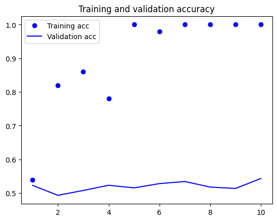

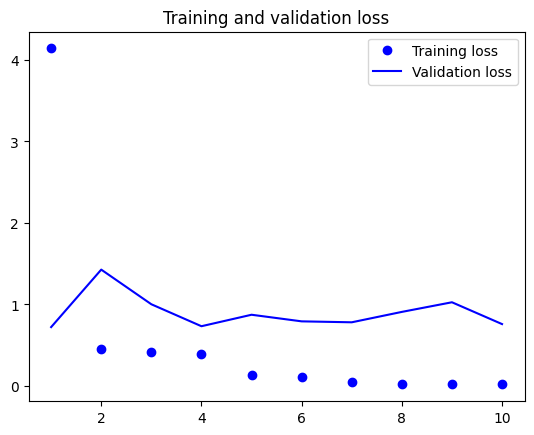

```
Training Accuracy = 1.0
Validation Accuracy = 0.5432999730110168
```

```python
model = Sequential()
model.add(Embedding(max_words, embedding_dim, input_length=maxlen))
model.add(Flatten())
model.add(Dense(32, activation='relu'))
model.add(Dense(1, activation='sigmoid'))
model.summary()
model.layers[0].set_weights([embedding_matrix])
model.layers[0].trainable = False

model.compile(optimizer='rmsprop',loss='binary_crossentropy',metrics=['acc'])
history = model.fit(x_train, y_train, epochs=10, batch_size=32, validation_data=(x_val, y_val))
model.save_weights('pre_trained_glove_model.h5')
acc = history.history['acc']
val_acc = history.history['val_acc']
loss = history.history['loss']
val_loss = history.history['val_loss']
epochs = range(1, len(acc) + 1)
plt.plot(epochs, acc, 'bo', label='Training acc')
plt.plot(epochs, val_acc, 'b', label='Validation acc')
plt.title('Training and validation accuracy')
plt.legend()
plt.figure()
plt.plot(epochs, loss, 'bo', label='Training loss')
plt.plot(epochs, val_loss, 'b', label='Validation loss')
plt.title('Training and validation loss')
plt.legend()
plt.show()

# Access the training and validation accuracy from the history by taking the last epoch's accuracy
training_accuracy = history.history['acc']
print(f"Training Accuracy = {training_accuracy[-1]}")

validation_accuracy = history.history['val_acc']
print(f"Validation Accuracy = {validation_accuracy[-1]}")
```

The above model is highly overfitting and should be overcome somehow to gain better model performance.

With a small number of training samples, the model's performance can be highly sensitive to the specific samples chosen for training. This sensitivity to the training set is a characteristic of models trained on limited data, and it's known as high variance.

In machine learning, high variance typically occurs when a model is too complex relative to the amount of training data available. The model may learn to fit the training data too closely, capturing noise and outliers rather than generalizing well to new, unseen data.

# It seems like the above model is overfitting and is because the training samples are very low in number

# Building a model without pre-trained word embedding

```python
model = Sequential()
model.add(Embedding(max_words, embedding_dim, input_length=maxlen))
model.add(Flatten())
model.add(Dense(32, activation='relu'))
model.add(Dense(1, activation='sigmoid'))
model.summary()
model.compile(optimizer='rmsprop',loss='binary_crossentropy',metrics=['acc'])
history = model.fit(x_train, y_train,epochs=10,batch_size=32,validation_data=(x_val, y_val))
```

```
Model: "sequential_28"
_________________________________________________________________
 Layer (type)                Output Shape              Param #
=================================================================
 embedding_28 (Embedding)    (None, 150, 100)          1000000

 flatten_20 (Flatten)        (None, 15000)             0

 dense_48 (Dense)            (None, 32)                480032

 dense_49 (Dense)            (None, 1)                 33

=================================================================
Total params: 1480065 (5.65 MB)
Trainable params: 1480065 (5.65 MB)
Non-trainable params: 0 (0.00 Byte)
_________________________________________________________________
```

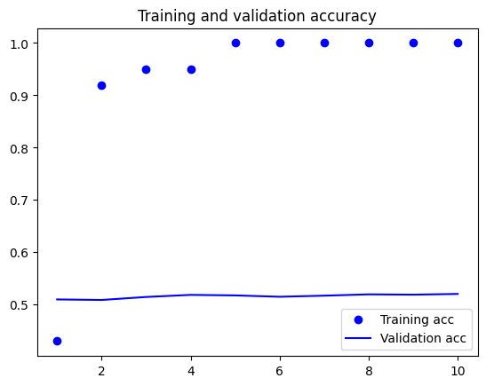

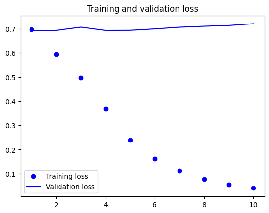

```python
acc = history.history['acc']
val_acc = history.history['val_acc']
loss = history.history['loss']
val_loss = history.history['val_loss']
epochs = range(1, len(acc) + 1)
plt.plot(epochs, acc, 'bo', label='Training acc')
plt.plot(epochs, val_acc, 'b', label='Validation acc')
plt.title('Training and validation accuracy')
plt.legend()
plt.figure()
plt.plot(epochs, loss, 'bo', label='Training loss')
plt.plot(epochs, val_loss, 'b', label='Validation loss')
plt.title('Training and validation loss')
plt.legend()
plt.show()
```

```python
# Access the training and validation accuracy from the history by taking the last epoch's accuracy
training_accuracy = history.history['acc']
print(f"Training Accuracy = {training_accuracy[-1]}")

validation_accuracy = history.history['val_acc']
print(f"Validation Accuracy = {validation_accuracy[-1]}")
```

```
Training Accuracy = 1.0
Validation Accuracy = 0.5202999711036682
```

```python
model.save_weights('no_pretrained_embeddings_model.h5')
```

# Model without using pre-trained word embeddings still is overfitting(modeled too closely to training data) which is no surprising as the training samples are just 100 in total and also is underperforming than the model that is using pre-trained word-embeddings.

# I will try to increase the training samples as per the question to around 1000

```python
maxlen = 150 # Cut off reviews after 150 words
training_samples = 1000 # Number of training samples
validation_samples = 10000 # Number of validation samples
max_words = 10000 # Consider only the top 10000 words

x_train, y_train, x_val, y_val, word_index = preprocess_text_data(texts, labels, max_words, maxlen, training_samples, validation_samples)

model = Sequential()
model.add(Embedding(max_words, embedding_dim, input_length=maxlen))
model.add(Flatten())
model.add(Dense(32, activation='relu'))
model.add(Dense(1, activation='sigmoid'))
model.summary()
model.compile(optimizer='rmsprop',loss='binary_crossentropy',metrics=['acc'])
history = model.fit(x_train, y_train,epochs=10,batch_size=32,validation_data=(x_val, y_val))
```

```
Found 88582 unique tokens.
Shape of data tensor: (25000, 150)
Shape of label tensor: (25000,)
Model: "sequential_29"
_________________________________________________________________
 Layer (type)                Output Shape              Param #
=================================================================
 embedding_29 (Embedding)    (None, 150, 100)          1000000

 flatten_21 (Flatten)        (None, 15000)             0

 dense_50 (Dense)            (None, 32)                480032

 dense_51 (Dense)            (None, 1)                 33

=================================================================
Total params: 1480065 (5.65 MB)
Trainable params: 1480065 (5.65 MB)
Non-trainable params: 0 (0.00 Byte)
_________________________________________________________________
```

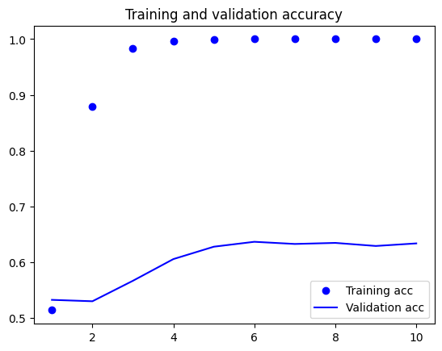

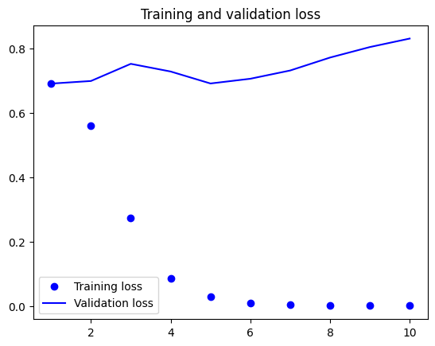

```python
acc = history.history['acc']
val_acc = history.history['val_acc']
loss = history.history['loss']
val_loss = history.history['val_loss']
epochs = range(1, len(acc) + 1)
plt.plot(epochs, acc, 'bo', label='Training acc')
plt.plot(epochs, val_acc, 'b', label='Validation acc')
plt.title('Training and validation accuracy')
plt.legend()
plt.figure()
plt.plot(epochs, loss, 'bo', label='Training loss')
plt.plot(epochs, val_loss, 'b', label='Validation loss')
plt.title('Training and validation loss')
plt.legend()
plt.show()
```

```python
# Access the training and validation accuracy from the history by taking the last epoch's accuracy
training_accuracy = history.history['acc']
print(f"Training Accuracy = {training_accuracy[-1]}")

validation_accuracy = history.history['val_acc']
print(f"Validation Accuracy = {validation_accuracy[-1]}")
```

```
Training Accuracy = 1.0
Validation Accuracy = 0.6338000297546387
```

# After increasing the training samples, there still seems to be overfitting. However, the validation accuracy has increased from 52% to 63.38%

```python
model.save_weights('no_pretrained_embeddings_w_1000_model.h5')
```

# lets increase the training samples to 2000

```python
maxlen = 150 # Cut off reviews after 150 words
training_samples = 2000 # Number of training samples
validation_samples = 10000 # Number of validation samples
max_words = 10000 # Consider only the top 10000 words

x_train, y_train, x_val, y_val, word_index = preprocess_text_data(texts, labels, max_words, maxlen, training_samples, validation_samples)

model = Sequential()
model.add(Embedding(max_words, embedding_dim, input_length=maxlen))
model.add(Flatten())
model.add(Dense(32, activation='relu'))
model.add(Dense(1, activation='sigmoid'))
model.summary()
model.compile(optimizer='rmsprop',loss='binary_crossentropy',metrics=['acc'])
history = model.fit(x_train, y_train,epochs=10,batch_size=32,validation_data=(x_val, y_val))
```

```
Found 88582 unique tokens.
Shape of data tensor: (25000, 150)
Shape of label tensor: (25000,)
Model: "sequential_30"
_________________________________________________________________
 Layer (type)                Output Shape              Param #
=================================================================
 embedding_30 (Embedding)    (None, 150, 100)          1000000

 flatten_22 (Flatten)        (None, 15000)             0

 dense_52 (Dense)            (None, 32)                480032

 dense_53 (Dense)            (None, 1)                 33

=================================================================
Total params: 1480065 (5.65 MB)
Trainable params: 1480065 (5.65 MB)
Non-trainable params: 0 (0.00 Byte)
_________________________________________________________________
```

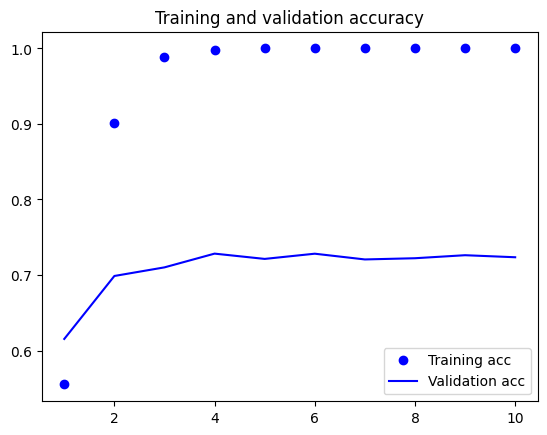

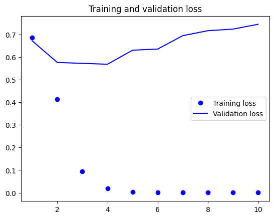

```python
acc = history.history['acc']
val_acc = history.history['val_acc']
loss = history.history['loss']
val_loss = history.history['val_loss']
epochs = range(1, len(acc) + 1)
plt.plot(epochs, acc, 'bo', label='Training acc')
plt.plot(epochs, val_acc, 'b', label='Validation acc')
plt.title('Training and validation accuracy')
plt.legend()
plt.figure()
plt.plot(epochs, loss, 'bo', label='Training loss')
plt.plot(epochs, val_loss, 'b', label='Validation loss')
plt.title('Training and validation loss')
plt.legend()
plt.show()
```

```python
# Access the training and validation accuracy from the history by taking the last epoch's accuracy
training_accuracy = history.history['acc']
print(f"Training Accuracy = {training_accuracy[-1]}")

validation_accuracy = history.history['val_acc']
print(f"Validation Accuracy = {validation_accuracy[-1]}")
```

```
Training Accuracy = 1.0
Validation Accuracy = 0.7235000133514404
```

```python
model.save_weights('no_pretrained_embeddings_w_2000_model.h5')
```

That is amazing, the validaiton accuracy keeps increasing as the number of training samples increase. Lets check when the performance stops increasing or flattens

Let us increase the training samples to 3000

```
Found 88582 unique tokens.
Shape of data tensor: (25000, 150)
Shape of label tensor: (25000,)
Model: "sequential_31"
_________________________________________________________________
 Layer (type)                Output Shape              Param #
=================================================================
 embedding_31 (Embedding)    (None, 150, 100)          1000000

 flatten_23 (Flatten)        (None, 15000)             0

 dense_54 (Dense)            (None, 32)                480032

 dense_55 (Dense)            (None, 1)                 33

=================================================================
Total params: 1480065 (5.65 MB)
Trainable params: 1480065 (5.65 MB)
Non-trainable params: 0 (0.00 Byte)
_________________________________________________________________
```

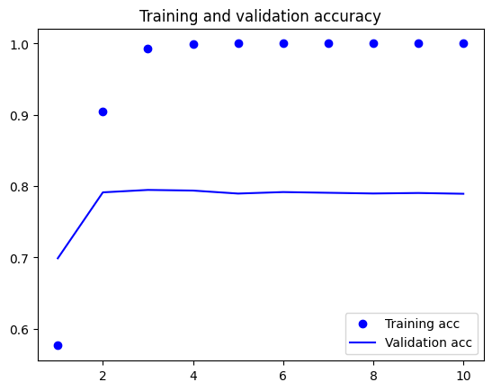

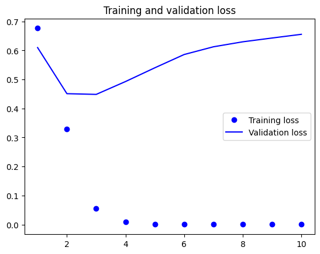

```
Training Accuracy = 1.0
Validation Accuracy = 0.7893000245094299
```

```python
maxlen = 150 # Cut off reviews after 150 words
training_samples = 3000 # Number of training samples
validation_samples = 10000 # Number of validation samples
max_words = 10000 # Consider only the top 10000 words

x_train, y_train, x_val, y_val, word_index = preprocess_text_data(texts, labels, max_words, maxlen, training_samples, validation_samples)

model = Sequential()
model.add(Embedding(max_words, embedding_dim, input_length=maxlen))
model.add(Flatten())
model.add(Dense(32, activation='relu'))
model.add(Dense(1, activation='sigmoid'))
model.summary()
model.compile(optimizer='rmsprop',loss='binary_crossentropy',metrics=['acc'])
history = model.fit(x_train, y_train,epochs=10,batch_size=32,validation_data=(x_val, y_val))

acc = history.history['acc']
val_acc = history.history['val_acc']
loss = history.history['loss']
val_loss = history.history['val_loss']
epochs = range(1, len(acc) + 1)
plt.plot(epochs, acc, 'bo', label='Training acc')
plt.plot(epochs, val_acc, 'b', label='Validation acc')
plt.title('Training and validation accuracy')
plt.legend()
plt.figure()
plt.plot(epochs, loss, 'bo', label='Training loss')
plt.plot(epochs, val_loss, 'b', label='Validation loss')
plt.title('Training and validation loss')
plt.legend()
plt.show()

# Access the training and validation accuracy from the history by taking the last epoch's accuracy
training_accuracy = history.history['acc']
print(f"Training Accuracy = {training_accuracy[-1]}")

validation_accuracy = history.history['val_acc']
print(f"Validation Accuracy = {validation_accuracy[-1]}")

model.save_weights('no_pretrained_embeddings_w_3000_model.h5')
```

That is amazing again, the validation accuracy keeps increasing as the number of training samples increase, but the percentage increase in the accuracy is decreasing as we go up.

Lets check when the performance stops increasing or flattens

Let us increase the training samples to 4000

```
Found 88582 unique tokens.
Shape of data tensor: (25000, 150)
Shape of label tensor: (25000,)
Model: "sequential_32"
_________________________________________________________________
 Layer (type)                Output Shape              Param #
=================================================================
 embedding_32 (Embedding)    (None, 150, 100)          1000000

 flatten_24 (Flatten)        (None, 15000)             0

 dense_56 (Dense)            (None, 32)                480032

 dense_57 (Dense)            (None, 1)                 33

=================================================================
Total params: 1480065 (5.65 MB)
Trainable params: 1480065 (5.65 MB)
Non-trainable params: 0 (0.00 Byte)
_________________________________________________________________
```

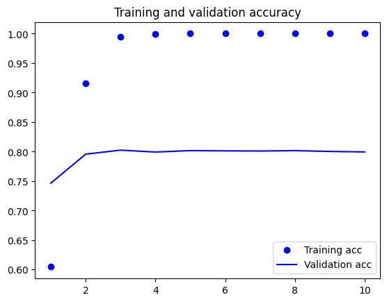

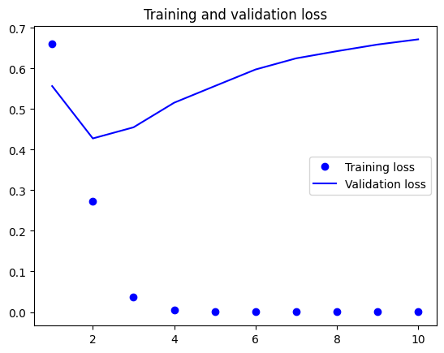

```
Training Accuracy = 1.0
Validation Accuracy = 0.7994999885559082
```

```python
maxlen = 150 # Cut off reviews after 150 words
training_samples = 4000 # Number of training samples
validation_samples = 10000 # Number of validation samples
max_words = 10000 # Consider only the top 10000 words

x_train, y_train, x_val, y_val, word_index = preprocess_text_data(texts, labels, max_words, maxlen, training_samples, validation_samples)

model = Sequential()
model.add(Embedding(max_words, embedding_dim, input_length=maxlen))
model.add(Flatten())
model.add(Dense(32, activation='relu'))
model.add(Dense(1, activation='sigmoid'))
model.summary()
model.compile(optimizer='rmsprop',loss='binary_crossentropy',metrics=['acc'])
history = model.fit(x_train, y_train,epochs=10,batch_size=32,validation_data=(x_val, y_val))

acc = history.history['acc']
val_acc = history.history['val_acc']
loss = history.history['loss']
val_loss = history.history['val_loss']
epochs = range(1, len(acc) + 1)
plt.plot(epochs, acc, 'bo', label='Training acc')
plt.plot(epochs, val_acc, 'b', label='Validation acc')
plt.title('Training and validation accuracy')
plt.legend()
plt.figure()
plt.plot(epochs, loss, 'bo', label='Training loss')
plt.plot(epochs, val_loss, 'b', label='Validation loss')
plt.title('Training and validation loss')
plt.legend()
plt.show()

# Access the training and validation accuracy from the history by taking the last epoch's accuracy
training_accuracy = history.history['acc']
print(f"Training Accuracy = {training_accuracy[-1]}")

validation_accuracy = history.history['val_acc']
print(f"Validation Accuracy = {validation_accuracy[-1]}")

model.save_weights('no_pretrained_embeddings_w_4000_model.h5')
```

The validation accuracy keeps increasing as the number of training samples increase, but the percentage increase in the accuracy is decreasing as we go up.

Lets check when the performance stops increasing or flattens

Let us increase the training samples to 5000

```
Found 88582 unique tokens.
Shape of data tensor: (25000, 150)
Shape of label tensor: (25000,)
Model: "sequential_33"
_________________________________________________________________
 Layer (type)                Output Shape              Param #
=================================================================
 embedding_33 (Embedding)    (None, 150, 100)          1000000

 flatten_25 (Flatten)        (None, 15000)             0

 dense_58 (Dense)            (None, 32)                480032

 dense_59 (Dense)            (None, 1)                 33

=================================================================
Total params: 1480065 (5.65 MB)
Trainable params: 1480065 (5.65 MB)
Non-trainable params: 0 (0.00 Byte)
_________________________________________________________________
```

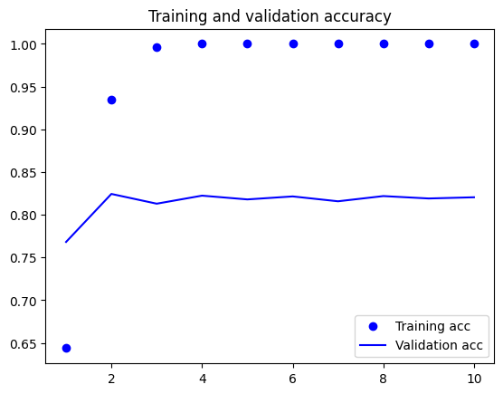

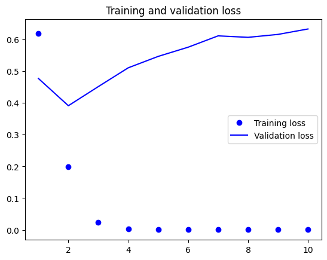

```
Training Accuracy = 1.0
Validation Accuracy = 0.8205000162124634
```

```python
maxlen = 150 # Cut off reviews after 150 words
training_samples = 5000 # Number of training samples
validation_samples = 10000 # Number of validation samples
max_words = 10000 # Consider only the top 10000 words

x_train, y_train, x_val, y_val, word_index = preprocess_text_data(texts, labels, max_words, maxlen, training_samples, validation_samples)

model = Sequential()
model.add(Embedding(max_words, embedding_dim, input_length=maxlen))
model.add(Flatten())
model.add(Dense(32, activation='relu'))
model.add(Dense(1, activation='sigmoid'))
model.summary()
model.compile(optimizer='rmsprop',loss='binary_crossentropy',metrics=['acc'])
history = model.fit(x_train, y_train,epochs=10,batch_size=32,validation_data=(x_val, y_val))

acc = history.history['acc']
val_acc = history.history['val_acc']
loss = history.history['loss']
val_loss = history.history['val_loss']
epochs = range(1, len(acc) + 1)
plt.plot(epochs, acc, 'bo', label='Training acc')
plt.plot(epochs, val_acc, 'b', label='Validation acc')
plt.title('Training and validation accuracy')
plt.legend()
plt.figure()
plt.plot(epochs, loss, 'bo', label='Training loss')
plt.plot(epochs, val_loss, 'b', label='Validation loss')
plt.title('Training and validation loss')
plt.legend()
plt.show()

# Access the training and validation accuracy from the history by taking the last epoch's accuracy
training_accuracy = history.history['acc']
print(f"Training Accuracy = {training_accuracy[-1]}")

validation_accuracy = history.history['val_acc']
print(f"Validation Accuracy = {validation_accuracy[-1]}")

model.save_weights('no_pretrained_embeddings_w_5000_model.h5')
```

Lets check when the performance stops increasing

Let us increase the training samples to 6000

```
Found 88582 unique tokens.
Shape of data tensor: (25000, 150)
Shape of label tensor: (25000,)
Model: "sequential_34"
_________________________________________________________________
 Layer (type)                Output Shape              Param #
=================================================================
 embedding_34 (Embedding)    (None, 150, 100)          1000000

 flatten_26 (Flatten)        (None, 15000)             0

 dense_60 (Dense)            (None, 32)                480032

 dense_61 (Dense)            (None, 1)                 33

=================================================================
Total params: 1480065 (5.65 MB)
Trainable params: 1480065 (5.65 MB)
Non-trainable params: 0 (0.00 Byte)
_________________________________________________________________
```

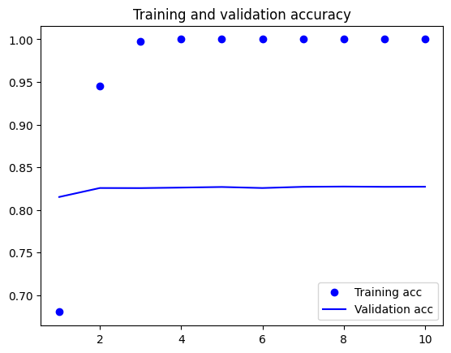

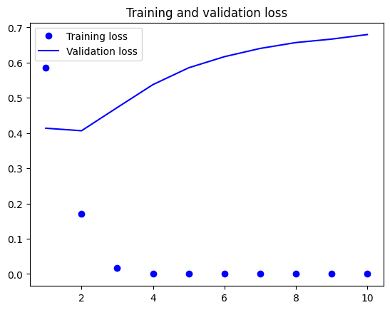

```
Training Accuracy = 1.0
Validation Accuracy = 0.8271999955177307
```

```python
maxlen = 150 # Cut off reviews after 150 words
training_samples = 6000 # Number of training samples
validation_samples = 10000 # Number of validation samples
max_words = 10000 # Consider only the top 10000 words

x_train, y_train, x_val, y_val, word_index = preprocess_text_data(texts, labels, max_words, maxlen, training_samples, validation_samples)

model = Sequential()
model.add(Embedding(max_words, embedding_dim, input_length=maxlen))
model.add(Flatten())
model.add(Dense(32, activation='relu'))
model.add(Dense(1, activation='sigmoid'))
model.summary()
model.compile(optimizer='rmsprop',loss='binary_crossentropy',metrics=['acc'])
history = model.fit(x_train, y_train,epochs=10,batch_size=32,validation_data=(x_val, y_val))

acc = history.history['acc']
val_acc = history.history['val_acc']
loss = history.history['loss']
val_loss = history.history['val_loss']
epochs = range(1, len(acc) + 1)
plt.plot(epochs, acc, 'bo', label='Training acc')
plt.plot(epochs, val_acc, 'b', label='Validation acc')
plt.title('Training and validation accuracy')
plt.legend()
plt.figure()
plt.plot(epochs, loss, 'bo', label='Training loss')
plt.plot(epochs, val_loss, 'b', label='Validation loss')
plt.title('Training and validation loss')
plt.legend()
plt.show()

# Access the training and validation accuracy from the history by taking the last epoch's accuracy
training_accuracy = history.history['acc']
print(f"Training Accuracy = {training_accuracy[-1]}")

validation_accuracy = history.history['val_acc']
print(f"Validation Accuracy = {validation_accuracy[-1]}")

model.save_weights('no_pretrained_embeddings_w_6000_model.h5')
```

Let us increase the training samples to 7000

```
Found 88582 unique tokens.
Shape of data tensor: (25000, 150)
Shape of label tensor: (25000,)
Model: "sequential_35"
_________________________________________________________________
 Layer (type)                Output Shape              Param #
=================================================================
 embedding_35 (Embedding)    (None, 150, 100)          1000000

 flatten_27 (Flatten)        (None, 15000)             0

 dense_62 (Dense)            (None, 32)                480032

 dense_63 (Dense)            (None, 1)                 33

=================================================================
Total params: 1480065 (5.65 MB)
Trainable params: 1480065 (5.65 MB)
Non-trainable params: 0 (0.00 Byte)
_________________________________________________________________
```

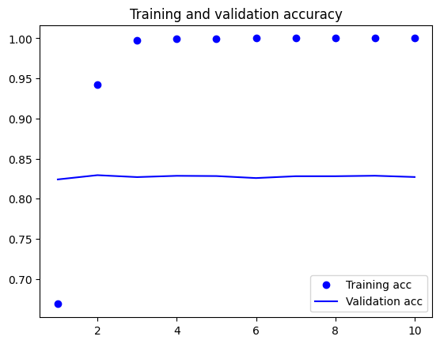

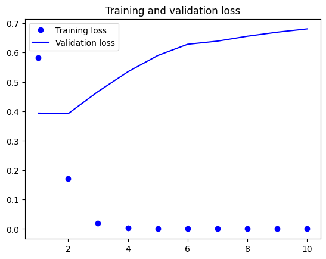

```
Training Accuracy = 1.0
Validation Accuracy = 0.8270999789237976
```

```python
maxlen = 150 # Cut off reviews after 150 words
training_samples = 7000 # Number of training samples
validation_samples = 10000 # Number of validation samples
max_words = 10000 # Consider only the top 10000 words

x_train, y_train, x_val, y_val, word_index = preprocess_text_data(texts, labels, max_words, maxlen, training_samples, validation_samples)

model = Sequential()
model.add(Embedding(max_words, embedding_dim, input_length=maxlen))
model.add(Flatten())
model.add(Dense(32, activation='relu'))
model.add(Dense(1, activation='sigmoid'))
model.summary()
model.compile(optimizer='rmsprop',loss='binary_crossentropy',metrics=['acc'])
history = model.fit(x_train, y_train,epochs=10,batch_size=32,validation_data=(x_val, y_val))

acc = history.history['acc']
val_acc = history.history['val_acc']
loss = history.history['loss']
val_loss = history.history['val_loss']
epochs = range(1, len(acc) + 1)
plt.plot(epochs, acc, 'bo', label='Training acc')
plt.plot(epochs, val_acc, 'b', label='Validation acc')
plt.title('Training and validation accuracy')
plt.legend()
plt.figure()
plt.plot(epochs, loss, 'bo', label='Training loss')
plt.plot(epochs, val_loss, 'b', label='Validation loss')
plt.title('Training and validation loss')
plt.legend()
plt.show()

# Access the training and validation accuracy from the history by taking the last epoch's accuracy
training_accuracy = history.history['acc']
print(f"Training Accuracy = {training_accuracy[-1]}")

validation_accuracy = history.history['val_acc']
print(f"Validation Accuracy = {validation_accuracy[-1]}")

model.save_weights('no_pretrained_embeddings_w_7000_model.h5')
```

It seems like the accuracy has flattened out at 7000 training samples

Let us increase the training samples to 10000 directly

```
Found 88582 unique tokens.
Shape of data tensor: (25000, 150)
Shape of label tensor: (25000,)
Model: "sequential_36"
_________________________________________________________________
 Layer (type)                Output Shape              Param #
=================================================================
 embedding_36 (Embedding)    (None, 150, 100)          1000000

 flatten_28 (Flatten)        (None, 15000)             0

 dense_64 (Dense)            (None, 32)                480032

 dense_65 (Dense)            (None, 1)                 33

=================================================================
Total params: 1480065 (5.65 MB)
Trainable params: 1480065 (5.65 MB)
Non-trainable params: 0 (0.00 Byte)
_________________________________________________________________
```

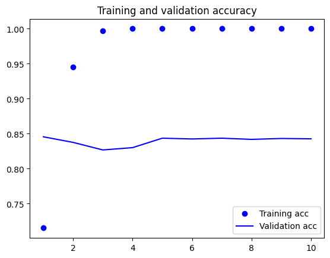

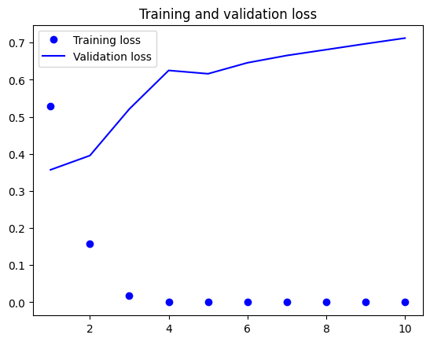

```
Training Accuracy = 1.0
Validation Accuracy = 0.8427000045776367
```

```python
maxlen = 150 # Cut off reviews after 150 words
training_samples = 10000 # Number of training samples
validation_samples = 10000 # Number of validation samples
max_words = 10000 # Consider only the top 10000 words

x_train, y_train, x_val, y_val, word_index = preprocess_text_data(texts, labels, max_words, maxlen, training_samples, validation_samples)

model = Sequential()
model.add(Embedding(max_words, embedding_dim, input_length=maxlen))
model.add(Flatten())
model.add(Dense(32, activation='relu'))
model.add(Dense(1, activation='sigmoid'))
model.summary()
model.compile(optimizer='rmsprop',loss='binary_crossentropy',metrics=['acc'])
history = model.fit(x_train, y_train,epochs=10,batch_size=32,validation_data=(x_val, y_val))

acc = history.history['acc']
val_acc = history.history['val_acc']
loss = history.history['loss']
val_loss = history.history['val_loss']
epochs = range(1, len(acc) + 1)
plt.plot(epochs, acc, 'bo', label='Training acc')
plt.plot(epochs, val_acc, 'b', label='Validation acc')
plt.title('Training and validation accuracy')
plt.legend()
plt.figure()
plt.plot(epochs, loss, 'bo', label='Training loss')
plt.plot(epochs, val_loss, 'b', label='Validation loss')
plt.title('Training and validation loss')
plt.legend()
plt.show()

# Access the training and validation accuracy from the history by taking the last epoch's accuracy
training_accuracy = history.history['acc']
print(f"Training Accuracy = {training_accuracy[-1]}")

validation_accuracy = history.history['val_acc']
print(f"Validation Accuracy = {validation_accuracy[-1]}")

model.save_weights('no_pretrained_embeddings_w_10000_model.h5')
```

That is amazing again, the validation accuracy keeps increasing as the number of training samples increase, but the percentage increase in the accuracy is decreasing as we go up. Now, the increase is super slow.

Lets check when the performance stops increasing

Let us increase the training samples to 15000 directly

```
Found 88582 unique tokens.
Shape of data tensor: (25000, 150)
Shape of label tensor: (25000,)
Model: "sequential_37"
_________________________________________________________________
 Layer (type)                Output Shape              Param #
=================================================================
 embedding_37 (Embedding)    (None, 150, 100)          1000000

 flatten_29 (Flatten)        (None, 15000)             0

 dense_66 (Dense)            (None, 32)                480032

 dense_67 (Dense)            (None, 1)                 33

=================================================================
Total params: 1480065 (5.65 MB)
Trainable params: 1480065 (5.65 MB)
Non-trainable params: 0 (0.00 Byte)
_________________________________________________________________
```

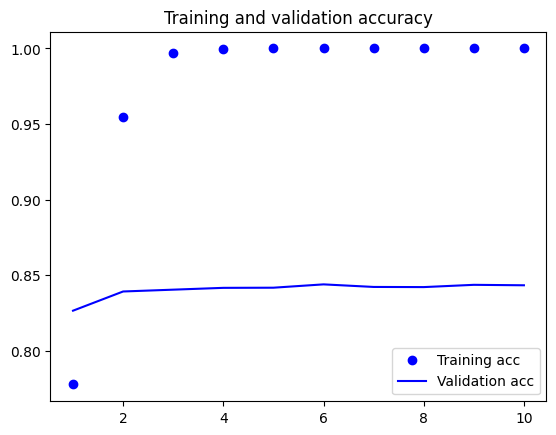

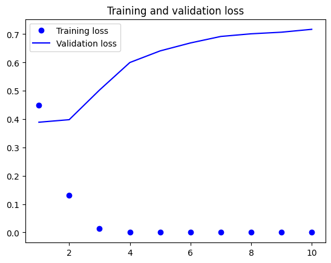

```
Training Accuracy = 1.0
Validation Accuracy = 0.8434000015258789
```

```python
maxlen = 150 # Cut off reviews after 150 words
training_samples = 15000 # Number of training samples
validation_samples = 10000 # Number of validation samples
max_words = 10000 # Consider only the top 10000 words

x_train, y_train, x_val, y_val, word_index = preprocess_text_data(texts, labels, max_words, maxlen, training_samples, validation_samples)

model = Sequential()
model.add(Embedding(max_words, embedding_dim, input_length=maxlen))
model.add(Flatten())
model.add(Dense(32, activation='relu'))
model.add(Dense(1, activation='sigmoid'))
model.summary()
model.compile(optimizer='rmsprop',loss='binary_crossentropy',metrics=['acc'])
history = model.fit(x_train, y_train,epochs=10,batch_size=32,validation_data=(x_val, y_val))

acc = history.history['acc']
val_acc = history.history['val_acc']
loss = history.history['loss']
val_loss = history.history['val_loss']
epochs = range(1, len(acc) + 1)
plt.plot(epochs, acc, 'bo', label='Training acc')
plt.plot(epochs, val_acc, 'b', label='Validation acc')
plt.title('Training and validation accuracy')
plt.legend()
plt.figure()
plt.plot(epochs, loss, 'bo', label='Training loss')
plt.plot(epochs, val_loss, 'b', label='Validation loss')
plt.title('Training and validation loss')
plt.legend()
plt.show()

# Access the training and validation accuracy from the history by taking the last epoch's accuracy
training_accuracy = history.history['acc']
print(f"Training Accuracy = {training_accuracy[-1]}")

validation_accuracy = history.history['val_acc']
print(f"Validation Accuracy = {validation_accuracy[-1]}")

model.save_weights('no_pretrained_embeddings_w_15000_model.h5')
```

The validation accuracy keeps increasing as the number of training samples increase, but the percentage increase in the accuracy is decreasing as we go up. Now, the accuracy is flattening at around 83-84% range.

# Lets check the models using pre-trained word embeddings

# First pre-trained word embedding i used in the beginning gave a validation accuracy of around 54% using just 100 training samples. Let us increase it to 1000

```
Found 88582 unique tokens.
Shape of data tensor: (25000, 150)
Shape of label tensor: (25000,)
Model: "sequential_38"
_________________________________________________________________
 Layer (type)                Output Shape              Param #
=================================================================
 embedding_38 (Embedding)    (None, 150, 100)          1000000

 flatten_30 (Flatten)        (None, 15000)             0

 dense_68 (Dense)            (None, 32)                480032

 dense_69 (Dense)            (None, 1)                 33

=================================================================
Total params: 1480065 (5.65 MB)
Trainable params: 1480065 (5.65 MB)
Non-trainable params: 0 (0.00 Byte)
_________________________________________________________________
```

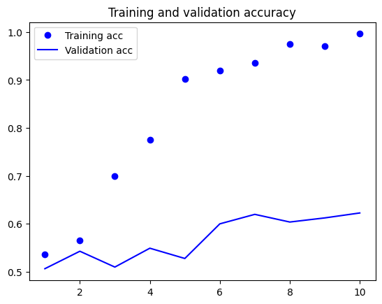

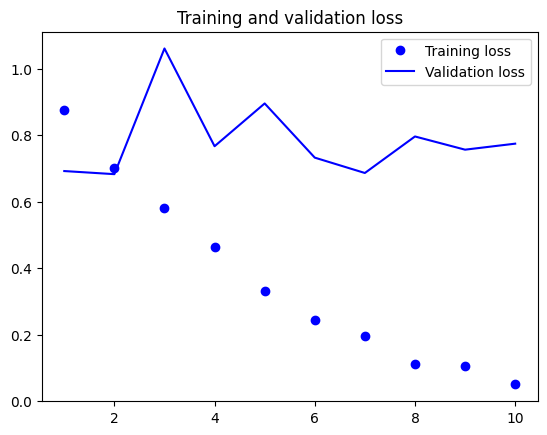

```
Training Accuracy = 0.9959999918937683
Validation Accuracy = 0.6226000189781189
```

```python
maxlen = 150 # Cut off reviews after 150 words
training_samples = 1000 # Number of training samples
validation_samples = 10000 # Number of validation samples
max_words = 10000 # Consider only the top 10000 words

x_train, y_train, x_val, y_val, word_index = preprocess_text_data(texts, labels, max_words, maxlen, training_samples, validation_samples)


model = Sequential()
model.add(Embedding(max_words, embedding_dim, input_length=maxlen))
model.add(Flatten())
model.add(Dense(32, activation='relu'))
model.add(Dense(1, activation='sigmoid'))
model.summary()
model.layers[0].set_weights([embedding_matrix])
model.layers[0].trainable = False

model.compile(optimizer='rmsprop',loss='binary_crossentropy',metrics=['acc'])
history = model.fit(x_train, y_train, epochs=10, batch_size=32, validation_data=(x_val, y_val))
model.save_weights('pre_trained_glove_model_w_1000.h5')


acc = history.history['acc']
val_acc = history.history['val_acc']
loss = history.history['loss']
val_loss = history.history['val_loss']
epochs = range(1, len(acc) + 1)
plt.plot(epochs, acc, 'bo', label='Training acc')
plt.plot(epochs, val_acc, 'b', label='Validation acc')
plt.title('Training and validation accuracy')
plt.legend()
plt.figure()
plt.plot(epochs, loss, 'bo', label='Training loss')
plt.plot(epochs, val_loss, 'b', label='Validation loss')
plt.title('Training and validation loss')
plt.legend()
plt.show()

# Access the training and validation accuracy from the history by taking the last epoch's accuracy
training_accuracy = history.history['acc']
print(f"Training Accuracy = {training_accuracy[-1]}")

validation_accuracy = history.history['val_acc']
print(f"Validation Accuracy = {validation_accuracy[-1]}")
```

# It seems like there is a significant increase in model validation accuracy from 54% to 62.26% is training accuracy is not 1 which means the overfitting problem is slightly getting prevented.

Lets increase the training samples to 2000

```
Found 88582 unique tokens.
Shape of data tensor: (25000, 150)
Shape of label tensor: (25000,)
Model: "sequential_39"
_________________________________________________________________
 Layer (type)                Output Shape              Param #
=================================================================
 embedding_39 (Embedding)    (None, 150, 100)          1000000

 flatten_31 (Flatten)        (None, 15000)             0

 dense_70 (Dense)            (None, 32)                480032

 dense_71 (Dense)            (None, 1)                 33

=================================================================
Total params: 1480065 (5.65 MB)
Trainable params: 1480065 (5.65 MB)
Non-trainable params: 0 (0.00 Byte)
_________________________________________________________________
```

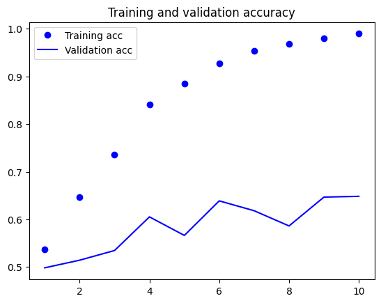

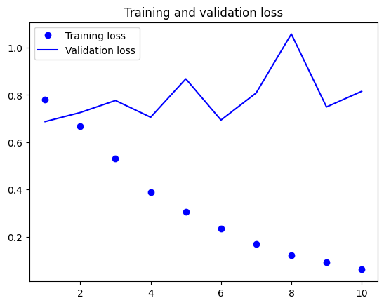

```
Training Accuracy = 0.9894999861717224
Validation Accuracy = 0.6482999920845032
```

```python
maxlen = 150 # Cut off reviews after 150 words
training_samples = 2000 # Number of training samples
validation_samples = 10000 # Number of validation samples
max_words = 10000 # Consider only the top 10000 words

x_train, y_train, x_val, y_val, word_index = preprocess_text_data(texts, labels, max_words, maxlen, training_samples, validation_samples)


model = Sequential()
model.add(Embedding(max_words, embedding_dim, input_length=maxlen))
model.add(Flatten())
model.add(Dense(32, activation='relu'))
model.add(Dense(1, activation='sigmoid'))
model.summary()
model.layers[0].set_weights([embedding_matrix])
model.layers[0].trainable = False

model.compile(optimizer='rmsprop',loss='binary_crossentropy',metrics=['acc'])
history = model.fit(x_train, y_train, epochs=10, batch_size=32, validation_data=(x_val, y_val))
model.save_weights('pre_trained_glove_model_2000_16.h5')


acc = history.history['acc']
val_acc = history.history['val_acc']
loss = history.history['loss']
val_loss = history.history['val_loss']
epochs = range(1, len(acc) + 1)
plt.plot(epochs, acc, 'bo', label='Training acc')
plt.plot(epochs, val_acc, 'b', label='Validation acc')
plt.title('Training and validation accuracy')
plt.legend()
plt.figure()
plt.plot(epochs, loss, 'bo', label='Training loss')
plt.plot(epochs, val_loss, 'b', label='Validation loss')
plt.title('Training and validation loss')
plt.legend()
plt.show()

# Access the training and validation accuracy from the history by taking the last epoch's accuracy
training_accuracy = history.history['acc']
print(f"Training Accuracy = {training_accuracy[-1]}")

validation_accuracy = history.history['val_acc']
print(f"Validation Accuracy = {validation_accuracy[-1]}")
```

Increasing to 3000 training samples

```
Found 88582 unique tokens.
Shape of data tensor: (25000, 150)
Shape of label tensor: (25000,)
Model: "sequential_40"
_________________________________________________________________
 Layer (type)                Output Shape              Param #
=================================================================
 embedding_40 (Embedding)    (None, 150, 100)          1000000

 flatten_32 (Flatten)        (None, 15000)             0

 dense_72 (Dense)            (None, 32)                480032

 dense_73 (Dense)            (None, 1)                 33

=================================================================
Total params: 1480065 (5.65 MB)
Trainable params: 1480065 (5.65 MB)
Non-trainable params: 0 (0.00 Byte)
_________________________________________________________________
```

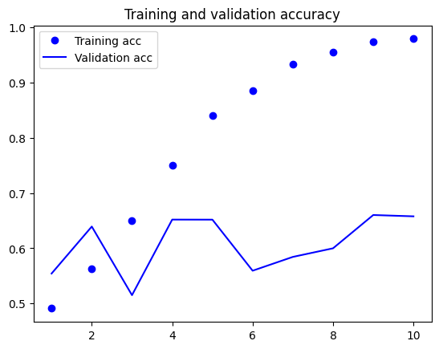

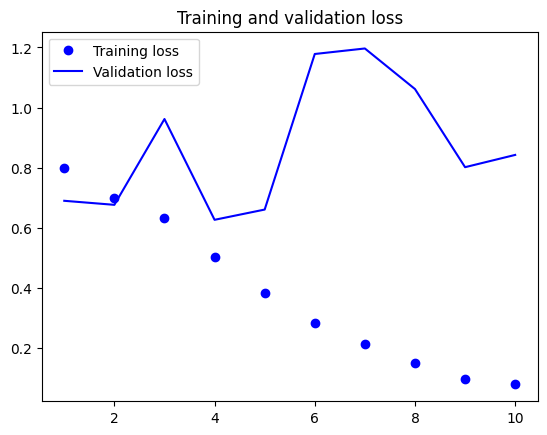

```
Training Accuracy = 0.9793333411216736
Validation Accuracy = 0.6578999757766724
```

```python
maxlen = 150 # Cut off reviews after 150 words
training_samples = 3000 # Number of training samples
validation_samples = 10000 # Number of validation samples
max_words = 10000 # Consider only the top 10000 words

x_train, y_train, x_val, y_val, word_index = preprocess_text_data(texts, labels, max_words, maxlen, training_samples, validation_samples)


model = Sequential()
model.add(Embedding(max_words, embedding_dim, input_length=maxlen))
model.add(Flatten())
model.add(Dense(32, activation='relu'))
model.add(Dense(1, activation='sigmoid'))
model.summary()
model.layers[0].set_weights([embedding_matrix])
model.layers[0].trainable = False

model.compile(optimizer='rmsprop',loss='binary_crossentropy',metrics=['acc'])
history = model.fit(x_train, y_train, epochs=10, batch_size=32, validation_data=(x_val, y_val))
model.save_weights('pre_trained_glove_model_3000_17.h5')


acc = history.history['acc']
val_acc = history.history['val_acc']
loss = history.history['loss']
val_loss = history.history['val_loss']
epochs = range(1, len(acc) + 1)
plt.plot(epochs, acc, 'bo', label='Training acc')
plt.plot(epochs, val_acc, 'b', label='Validation acc')
plt.title('Training and validation accuracy')
plt.legend()
plt.figure()
plt.plot(epochs, loss, 'bo', label='Training loss')
plt.plot(epochs, val_loss, 'b', label='Validation loss')
plt.title('Training and validation loss')
plt.legend()
plt.show()

# Access the training and validation accuracy from the history by taking the last epoch's accuracy
training_accuracy = history.history['acc']
print(f"Training Accuracy = {training_accuracy[-1]}")

validation_accuracy = history.history['val_acc']
print(f"Validation Accuracy = {validation_accuracy[-1]}")
```

The validation accuracy actually increased from previous model from 64.83%(2000) to 65.79%(3000) and is also higher than the model with 1000 training samples

The percentage increase is super low compared to the percentage increase in the validation accuracy for model with 100 training samples to model with 1000 training samples

Lets increase it to 5000 training samples

```
Found 88582 unique tokens.
Shape of data tensor: (25000, 150)
Shape of label tensor: (25000,)
Model: "sequential_41"
_________________________________________________________________
 Layer (type)                Output Shape              Param #
=================================================================
 embedding_41 (Embedding)    (None, 150, 100)          1000000

 flatten_33 (Flatten)        (None, 15000)             0

 dense_74 (Dense)            (None, 32)                480032

 dense_75 (Dense)            (None, 1)                 33

=================================================================
Total params: 1480065 (5.65 MB)
Trainable params: 1480065 (5.65 MB)
Non-trainable params: 0 (0.00 Byte)
_________________________________________________________________
```

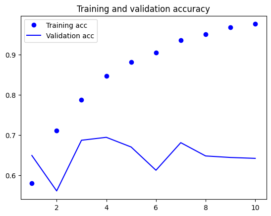

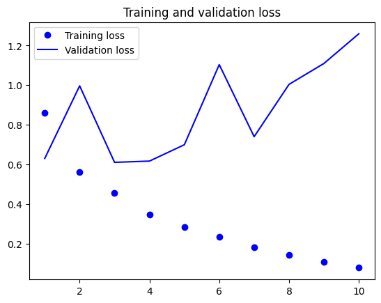

```
Training Accuracy = 0.9764000177383423
Validation Accuracy = 0.6419000029563904
```

```python
maxlen = 150 # Cut off reviews after 150 words
training_samples = 5000 # Number of training samples
validation_samples = 10000 # Number of validation samples
max_words = 10000 # Consider only the top 10000 words

x_train, y_train, x_val, y_val, word_index = preprocess_text_data(texts, labels, max_words, maxlen, training_samples, validation_samples)


model = Sequential()
model.add(Embedding(max_words, embedding_dim, input_length=maxlen))
model.add(Flatten())
model.add(Dense(32, activation='relu'))
model.add(Dense(1, activation='sigmoid'))
model.summary()
model.layers[0].set_weights([embedding_matrix])
model.layers[0].trainable = False

model.compile(optimizer='rmsprop',loss='binary_crossentropy',metrics=['acc'])
history = model.fit(x_train, y_train, epochs=10, batch_size=32, validation_data=(x_val, y_val))
model.save_weights('pre_trained_glove_model_5000_18.h5')


acc = history.history['acc']
val_acc = history.history['val_acc']
loss = history.history['loss']
val_loss = history.history['val_loss']
epochs = range(1, len(acc) + 1)
plt.plot(epochs, acc, 'bo', label='Training acc')
plt.plot(epochs, val_acc, 'b', label='Validation acc')
plt.title('Training and validation accuracy')
plt.legend()
plt.figure()
plt.plot(epochs, loss, 'bo', label='Training loss')
plt.plot(epochs, val_loss, 'b', label='Validation loss')
plt.title('Training and validation loss')
plt.legend()
plt.show()

# Access the training and validation accuracy from the history by taking the last epoch's accuracy
training_accuracy = history.history['acc']
print(f"Training Accuracy = {training_accuracy[-1]}")

validation_accuracy = history.history['val_acc']
print(f"Validation Accuracy = {validation_accuracy[-1]}")
```

There is a decrease in the validation accuracy from 65.79% to 64.19% with using 5000 samples.

Lets bump it up to 7500 training samples

```
Found 88582 unique tokens.
Shape of data tensor: (25000, 150)
Shape of label tensor: (25000,)
Model: "sequential_42"
_________________________________________________________________
 Layer (type)                Output Shape              Param #
=================================================================
 embedding_42 (Embedding)    (None, 150, 100)          1000000

 flatten_34 (Flatten)        (None, 15000)             0

 dense_76 (Dense)            (None, 32)                480032

 dense_77 (Dense)            (None, 1)                 33

=================================================================
Total params: 1480065 (5.65 MB)
Trainable params: 1480065 (5.65 MB)
Non-trainable params: 0 (0.00 Byte)
_________________________________________________________________
```

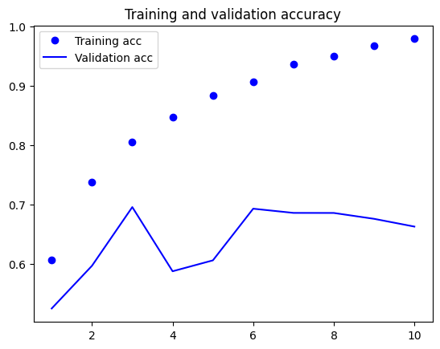

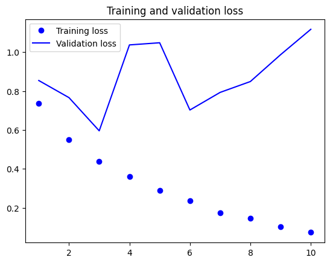

```
Training Accuracy = 0.979200005531311
Validation Accuracy = 0.6624000072479248
```

```python
maxlen = 150 # Cut off reviews after 150 words
training_samples = 7500 # Number of training samples
validation_samples = 10000 # Number of validation samples
max_words = 10000 # Consider only the top 10000 words

x_train, y_train, x_val, y_val, word_index = preprocess_text_data(texts, labels, max_words, maxlen, training_samples, validation_samples)


model = Sequential()
model.add(Embedding(max_words, embedding_dim, input_length=maxlen))
model.add(Flatten())
model.add(Dense(32, activation='relu'))
model.add(Dense(1, activation='sigmoid'))
model.summary()
model.layers[0].set_weights([embedding_matrix])
model.layers[0].trainable = False

model.compile(optimizer='rmsprop',loss='binary_crossentropy',metrics=['acc'])
history = model.fit(x_train, y_train, epochs=10, batch_size=32, validation_data=(x_val, y_val))
model.save_weights('pre_trained_glove_model_7500_19.h5')


acc = history.history['acc']
val_acc = history.history['val_acc']
loss = history.history['loss']
val_loss = history.history['val_loss']
epochs = range(1, len(acc) + 1)
plt.plot(epochs, acc, 'bo', label='Training acc')
plt.plot(epochs, val_acc, 'b', label='Validation acc')
plt.title('Training and validation accuracy')
plt.legend()
plt.figure()
plt.plot(epochs, loss, 'bo', label='Training loss')
plt.plot(epochs, val_loss, 'b', label='Validation loss')
plt.title('Training and validation loss')
plt.legend()
plt.show()

# Access the training and validation accuracy from the history by taking the last epoch's accuracy
training_accuracy = history.history['acc']
print(f"Training Accuracy = {training_accuracy[-1]}")

validation_accuracy = history.history['val_acc']
print(f"Validation Accuracy = {validation_accuracy[-1]}")
```